# Writing system matrix utilities

W. Bauer

July 19, 2015

This is a design document for utilities pertaining to analysis of system matrices, which are known to have non-zero kernels, even in favorable configurations.

### Utilities

The basic setup will be a pixelated test image consisting of a matrix of slowness (reciprocal speed of sound) values. R allows objects such as matrices to have attributes. Function `testImage` creates a matrix with attributes, `spacing`, for pixel spacing (dimension of a side in mm,) and `slowness` for the default value of slowness in a pixel. If slowness is not specified, `1/1500` mm/ms is used.

```r
source("../R/system_matrix_utils.R")
img <- testImage(32, 32, 1.25)
```

Representative speeds of sound in tissues of interest are given in the vector, `speed`. Available speeds are fat, gland, benign, malignant, silicone, alcohol, water.

The test image may be modified to include a rectangular area of gland by R subsetting:

```r
img[4:8, 8:24] <- 1/speed["gland"]
```

(Reference: [Nebeker and Nelson](http://www.jultrasoundmed.org/content/31/9/1389.full) “Mean values from published sound speed reports are as follows: fat, 1478 m/s; glandular breast, 1510 m/s; benign breast tumors, 1513 m/s; and malignant breast tumors, 1548 m/s”)

R’s default convention for displaying images is that rows index the x dimension from left to right, and columns index the y dimension from bottom to top. Thus, the “gland” occupies a rectangle at the vertical center on the left of the image. Function `plotTestImage` plots the test image with x and y dimensions labeled appropriately. Function `gridOverlay` plots grid lines over the image.

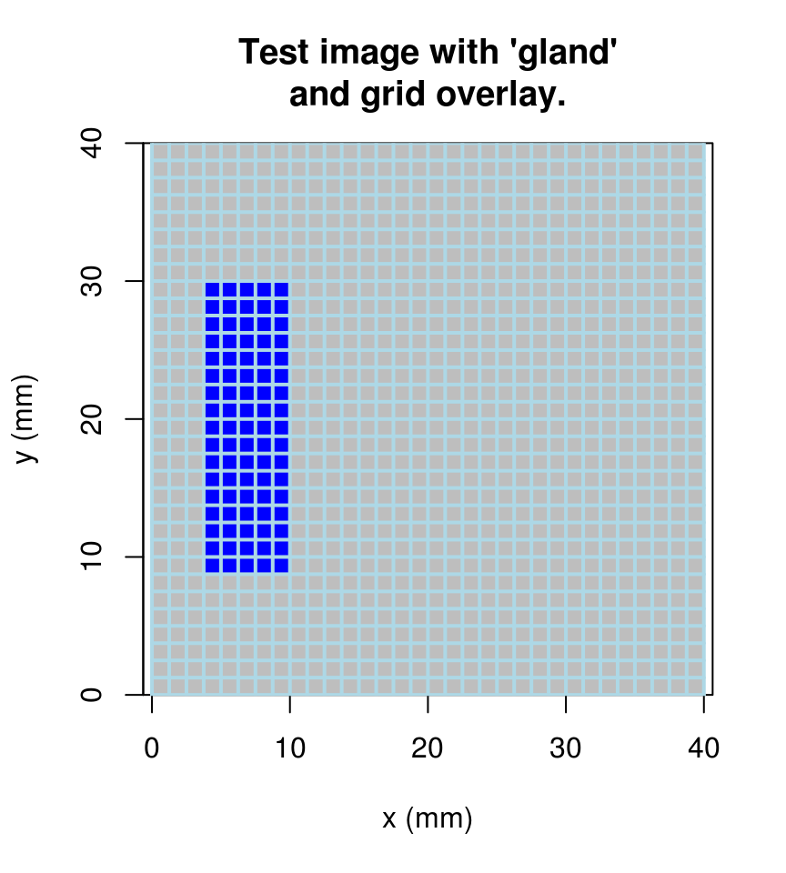

```r
plotTestImage(img, col=c("blue", "gray"), main="Test image with 'gland'\nand grid overlay.")
gridOverlay(img)
```

For present purposes it’s sufficient that probes be aligned at the left and right boundaries of a test image, and that they span the image vertically. Transducer y coordinates will thus be the same for both probes, and will be determined by the number of transducers per probe. Function `probeYs` calculates them.

```r
ys <- probeYs(32, img)
```

Function `probeOverlay` will plot transducer positions on the active plot of a test image.

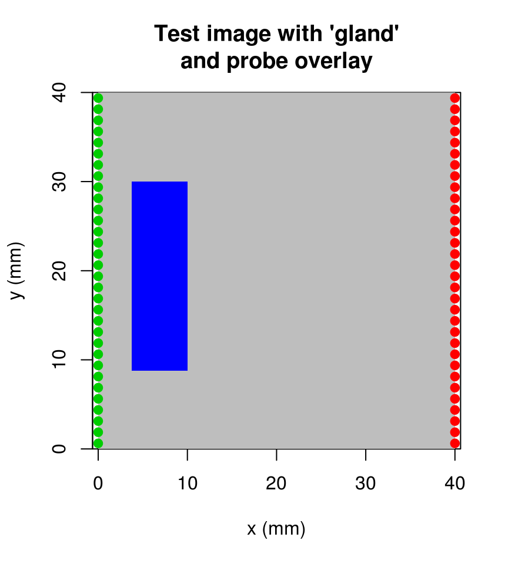

```r
plotTestImage(img, col=c("blue", "gray"), main="Test image with 'gland'\nand probe overlay")
probeOverlay(ys, img)
```

Function `pathOverlay` will plot a transmitter-to-receiver path on the active plot of a test image.

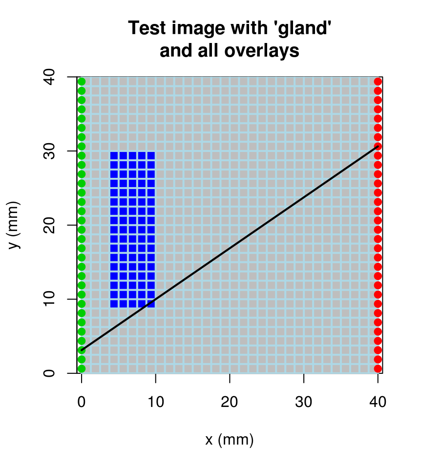

```r
plotTestImage(img, col=c("blue", "gray"), main="Test image with 'gland'\nand all overlays")
gridOverlay(img)
probeOverlay(ys, img)
pathOverlay(ys, img, transmitter = 3, receiver = 25)
```

Finally, function `sysMat(probe_ys, test_image, check=FALSE, MatrixPackage=FALSE)` will return a system matrix (or Matrix if MatrixPackage=TRUE) for the given probe coordinates and test image. If the `check` parameter is `TRUE`, entries will be checked to ensure that segment lengths along a path sum to the distance between the associated transmitter and receiver. Function `sysMat` is a rewrite of function `createSij`.

The default invocation of `sysMat` will return an ordinary R (lower case m) matrix. Warning: it will take some time to execute.

```r
S <- sysMat(ys, img)
```

Setting parameter `MatrixPackage=TRUE` causes a (upper case M) Matrix from the associated package to be returned. These objects are advantageous for handling sparse matrices.

```r
library(Matrix)
S <- sysMat(ys, img, MatrixPackage = TRUE)
```

Setting parameter `check = TRUE` checks that path segments sum to the proper path length, hence that no line segments have been dropped due to precision problems.

```r
# For a Matrix:
S <- sysMat(ys, img, MatrixPackage = TRUE, check=TRUE)
# For a matrix:
S <- sysMat(ys, img, check=TRUE)
```

### Scanning and image reconstruction

Scanning an image is a matter of matrix multiplication. The test image must first be converted to a vector.

```r
tau <- S %*% as.vector(img) # tau is times of flight
```

As shown earlier, system matrices will always have certain, stylized null vectors. Solutions, $b$, to $Sb \appox \tau$ will thus never be unique. Since the stylized null vectors can result in vertical stripes, I’ll call the space of stylized null vectors, the *stripe space.* Though the kernel of $S$ may be strictly larger than the stripe space, the orthogonal complement of the stripe space is of interest.

The orthogonal complement of the stripe space corresponds to images in which the sum of values in each column of pixels is the same for every column. For instance, the following image has the value `1/speed["fat"]` (light) in one pixel of each column and the default value, `1/1500` (dark) in the others:

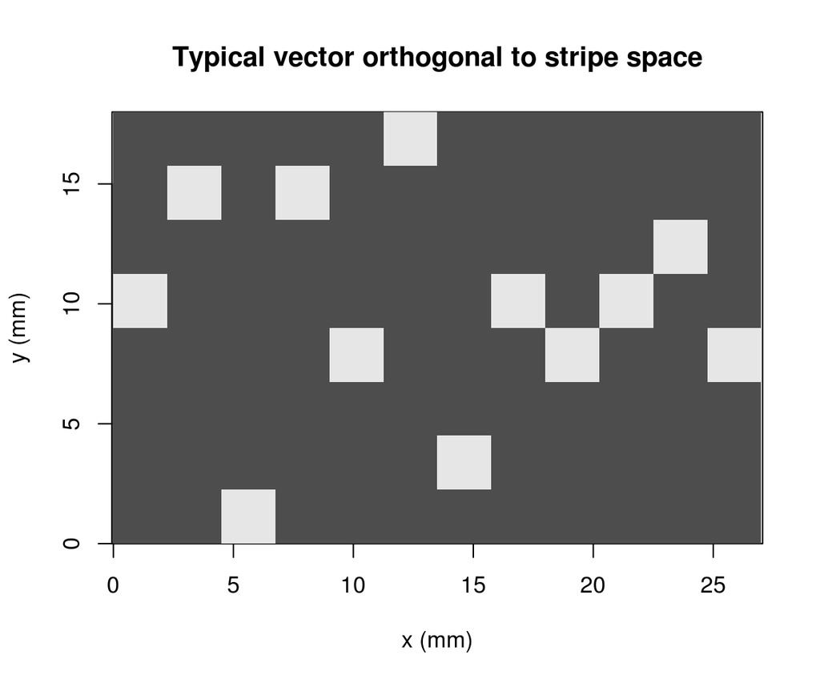

```r
orthogimg <- testImage(12, 8, 2.25)
set.seed(1437528807)
for(i in 1:12)orthogimg[i, sample(8,1)] <- 1/speed["fat"]
plotTestImage(orthogimg, col=gray.colors(2), main="Typical vector orthogonal to stripe space")
```

In R, pixel columns correspond to the y dimension. Equivalently, they correspond to the rows of the matrix which contains the image. Hence the row sums of `orthogimg` will be equal.

```r
rowSums(orthogimg)
```

```
##  [1] 0.005343257 0.005343257 0.005343257 0.005343257 0.005343257
##  [6] 0.005343257 0.005343257 0.005343257 0.005343257 0.005343257
## [11] 0.005343257 0.005343257
```

Restricting solutions to the orthogonal complement of the stripe space may be a good idea. Real images, of course, will not have the same sum in every pixel column, so such solutions will be incorrect, but will at least be unique in cases for which the stripe space is the entire kernel. It would then remain to remove stripe artifacts from the solution.

It is easy to specify a basis for the orthogonal complement of the stripe space. If the columns of $B$ are such a basis, solving $SBu \approx \tau$ for $u$ and letting $b = Bu$ would restrict solutions to the orthogonal complement.

A basis such that for any pair of basis vectors, $v$ and $w$, $Sv$ and $Sv$ are orthogonal, i.e. $Sv \bullet Sw = 0,$ would be particularly useful since the associate solution is a series of independent single variable optimizations, one for each vector. This is the principle behind optimization by conjugate gradient for instance.